# Study A: Exploring scRNA-seq data from 5 cancer cell lines with scBubbletree

SK

This vignette introduces `scBubbletree`, a transparent workflow for exploration of single cell RNA-seq data. To run this vignette we need a few R-packages:

```r
library(scBubbletree)
library(Seurat)
library(ggrepel)
```

## Data[^1]

Here we will analyze a scRNA-seq dataset containing a mixture of 3,918 cells from five human lung adenocarcinoma cell lines (HCC827, H1975, A549, H838 and H2228). The dataset is available here[^2].

The library was prepared with 10x Chromium platform and sequencing was performed with Illumina NextSeq 500 platform. Raw data was processed with Cellranger. The tool demuxlet was used to predict the identity of each cell based on known genetic differences between the different cell lines.

```r
# create directory
dir.create(path = "case_study_A/")


# download the data from:
https://github.com/LuyiTian/sc_mixology/raw/master/data/sincell_with_class_5cl.RData


# load the data
load(file = "case_study_A/sincell_with_class_5cl.RData")


# we are only interested in the 10x data object 'sce_sc_10x_5cl_qc'
d <- sce_sc_10x_5cl_qc


# remove the remaining objects (cleanup)
rm(sc_Celseq2_5cl_p1, sc_Celseq2_5cl_p2, sc_Celseq2_5cl_p3, sce_sc_10x_5cl_qc)


# get the meta data for each cell
meta <- colData(d)[, c("cell_line_demuxlet", "non_mt_percent", "total_features")]


# create Seurat object from the raw counts and append the meta data to it
d <- Seurat::CreateSeuratObject(counts = d@assays$data$counts,
                                project = '')


# check if all cells are matched between d and meta
# table(rownames(d@meta.data) == meta@rownames)
d@meta.data <- cbind(d@meta.data, meta@listData)


# cell type predictions are provided as part of the meta data
table(d@meta.data$cell_line)


# select 5,000 most variable genes
d <- Seurat::FindVariableFeatures(object = d,
                                  selection.method = "vst",
                                  nfeatures = 5000)

# Preprocessing with Seurat: SCT transformation + PCA + UMAP
d <- SCTransform(object = d,
                 variable.features.n = 5000)
d <- RunPCA(object = d,
            npcs = 50,
            features = VariableFeatures(object = d))

d <- RunUMAP(d, dims = 1:15)
d <- RunTSNE(d, dims = 1:15)

save(d, file = "case_study_A/d.RData")
```

## scBubbletree

We will analyze this data with `scBubbletree`.

As first input `scBubbletree` uses matrix $A^{n\times f}$ which represents a low-dimensional projection of the original scRNA-seq data, with $n$ rows as cells and $f$ columns as low-dimension features.

We will use the PCA data generated by `Seurat` as $A$. In particular, we will use the first 15 principal components (PCs) as every additional PC explains negligible amount of variance in the data.

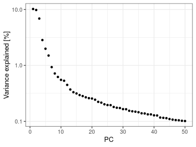

```r
var_explained <- ((d[["pca"]]@stdev)^2)/d[["pca"]]@misc$total.variance

g_var_explained <- ggplot(data = data.frame(var_explained = var_explained*100,
                                            PC = 1:length(var_explained)))+
  geom_point(aes(y = var_explained, x = PC), size = 1)+
  ylab(label = "Variance explained [%]")+
  scale_y_log10()

g_var_explained
```

```r
# This is the main input of scBubbletree -> matrix A
A <- d@reductions$pca@cell.embeddings[, 1:15]


# A has n=cells as rows, f=features as columns (e.g. from PCA)
dim(A)
```

```
FALSE [1] 3918   15
```

The `scBubbletree` workflow performs the following steps:

1. determine the clustering resolution (number of clusters $k$ or resolution $r$)
2. clustering with $k$-means and Louvain
3. hierarchical organization of clusters (bubbles)
4. visualization

### 1. determine the clustering resolution

If we want to use the k-means clustering algorithm for this step we need to find a reasonable value of the number of clusters $k$. We can also the Louvain algorithm in which case we need to find an appropriate value for the resolution parameter $r$.

#### 1.1 determining the number of clusters $k$

How many clusters (cell types) are there are in the data? Can we guess a reasonable value of $k$?

To find a reasonable value of $k$ we can study the literature or databases such as the human protein atlas database (HPA). We can also use the function `get_k` for data-driven inference of $k$ based on the Gap statistic and the within- cluster sum of squares (WCSS).

As this is a toy dataset, we will skip the first approach and perform a data-driven search for $k$ using `get_k`. As input we need to provide the matrix $A$ as input and a vector of $k$s. The output will be the Gap statistic and WCSS estimates for each $k$.

Lets run `get_k` now:

```r
b_k <- get_k(B_gap = 20,
             ks = 1:20,
             x = A,
             n_start = 100,
             iter_max = 200,
             kmeans_algorithm = "MacQueen",
             cores = 20)
```

```
FALSE 1) clustering
FALSE 2) gap-stat
FALSE 3) WCSS
```

The Gap statistic and WCSS curves have a noticeable knee (elbow) at $k=5$. Hence, $k$=5 appears to be reasonable first choice of $k$. Means (points) and 95% confidence intervals are shown for the Gap statistic at each $k$ computed using `B_gap`=20 MCMC simulations.

```r
g0 <- ggplot(data = b_k$gap_stats_summary)+
  geom_point(aes(x = k, y = gap_mean), size = 1)+
  geom_errorbar(aes(x = k, y = gap_mean, ymin = L95, ymax = H95), width = 0.1)+
  ylab(label = "Gap")|
ggplot(data = b_k$wcss_stats_summary)+
  geom_point(aes(x = k, y = wcss_mean), size = 1)+
  ylab(label = "WCSS")+
  scale_y_log10()+
  annotation_logticks(base = 10, sides = "l")
```

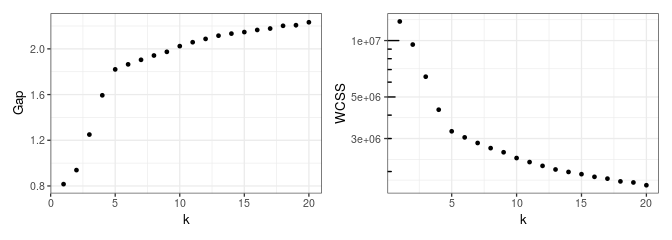

```r
g0
```

#### 1.2 determining the resolution parameter $r$

For Louvain clustering we need to select a clustering resolution $r$. Higher resolutions lead to more communities and lower resolutions lead to fewer communities. We can use the same strategy as before to find a reasonable reasonable value of $r$.

Lets use the function `get_r` for data-driven estimation of $r$ based on the Gap statistic and WCSS. As input we need to provide the matrix $A$ and a vector of $r$s. The output will be the Gap statistic and WCSS estimate for each $r$ (or the number of communities $k'$ detected at resolution $r$).

```r
b_r <- get_r(B_gap = 20,
             rs = 10^seq(from = -4, to = 1, by = 0.1),
             x = A,
             n_start = 20,
             iter_max = 100,
             louvain_algorithm = "original",
             cores = 20)
```

```
FALSE 1) clustering
FALSE 2) gap statistic
FALSE 3) WCSS
```

The Gap statistic and WCSS curves have a noticeable knee (elbow) at $k=5$. Means (points) and 95% confidence intervals are shown for the Gap statistic at each $k$ computed using `B_gap`=20 MCMC simulations.

```r
g0_r <- ggplot(data = b_r$gap_stats_summary)+
  geom_point(aes(x = k, y = gap_mean), size = 1)+
  geom_errorbar(aes(x = k, y = gap_mean, ymin = L95, ymax = H95), width = 0.1)+
  ylab(label = "Gap")+
  xlab(label = "k'")|
ggplot(data = b_r$wcss_stats_summary)+
  geom_point(aes(x = k, y = wcss_mean), size = 1)+
  ylab(label = "WCSS")+
  xlab(label = "k'")
```

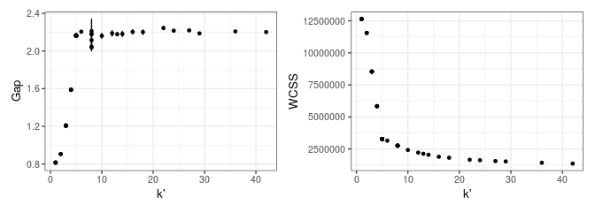

```r
g0_r
```

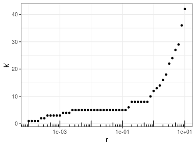

| gap_mean | r | k | gap_SE | L95 | H95 |
| --- | --- | --- | --- | --- | --- |
| 2.1651 | 0.0025 | 5 | 0.0053 | 2.1548 | 2.1755 |
| 2.1654 | 0.0032 | 5 | 0.0058 | 2.1539 | 2.1768 |
| 2.1645 | 0.0040 | 5 | 0.0041 | 2.1564 | 2.1726 |
| 2.1650 | 0.0050 | 5 | 0.0041 | 2.1570 | 2.1730 |
| 2.1651 | 0.0063 | 5 | 0.0045 | 2.1563 | 2.1739 |
| 2.1640 | 0.0079 | 5 | 0.0049 | 2.1544 | 2.1735 |
| 2.1652 | 0.0100 | 5 | 0.0052 | 2.1550 | 2.1754 |
| 2.1657 | 0.0126 | 5 | 0.0037 | 2.1584 | 2.1729 |
| 2.1647 | 0.0158 | 5 | 0.0047 | 2.1556 | 2.1739 |
| 2.1652 | 0.0200 | 5 | 0.0041 | 2.1572 | 2.1731 |
| 2.1664 | 0.0251 | 5 | 0.0045 | 2.1576 | 2.1752 |
| 2.1652 | 0.0316 | 5 | 0.0034 | 2.1585 | 2.1718 |
| 2.1650 | 0.0398 | 5 | 0.0047 | 2.1559 | 2.1742 |
| 2.1663 | 0.0501 | 5 | 0.0045 | 2.1575 | 2.1752 |
| 2.1650 | 0.0631 | 5 | 0.0056 | 2.1540 | 2.1760 |
| 2.1658 | 0.0794 | 5 | 0.0059 | 2.1542 | 2.1773 |
| 2.1669 | 0.1000 | 5 | 0.0037 | 2.1596 | 2.1742 |
| 2.1649 | 0.1259 | 5 | 0.0039 | 2.1572 | 2.1727 |

```r
ggplot(data = b_r$gap_stats_summary)+
    geom_point(aes(x = r, y = k), size = 1)+
    xlab(label = "r")+
    ylab(label = "k'")+
  scale_x_log10()+
  annotation_logticks(base = 10, sides = "b")
```

### 2. clustering

#### 2.1 with k-means

Now that we found out that $k=5$ is a reasonable choice based on the data, we will perform k-means clustering with $k=5$ and $A$ as inputs. For this we will use the function kmeans (R-package stats) which offers various variants of k-means. Here we will use MacQueen’s k-means variant and perform $n_{start} = 1000$ (default in scBubbletree) random starts and a maximum number of iterations $iter_{max}=300$.

**Important remark**: for smaller datasets (e.g. $n<50,000$) $n_{start}=1000$ and $n_{iter} = 300$ are unnecessarily high, however for larger datasets this is necessary to make sure that k-means converges.

### 3. hierarchical grouping

After the clustering is complete we will organize the bubbles in a natural hierarchy. For this we perform $B$ bootstrap iterations (default $B=200$). In iteration $b$ the algorithm draws a random subset of $N_{eff}$ (default $N_{eff}=200$) cells with replacement from each cluster and computes the average inter-cluster Euclidean distances. This data is used to populate the distance matrix ($D^{k\times k}_b$), which is provided as input for hierarchical clustering with average linkage to generate a hierarchical clustering dendrogram $H_b$.

The collection of distance matrices that are computed during $B$ iterations are used to compute a consensus (average) distance matrix ($\hat{D}^{k\times k}$) and from this a corresponding consensus hierarchical dendrogram (bubbletree; $\hat{H}$) is constructed. The collection of dendrograms are used to quantify the robustness of the bubbletree topology, i.e. to count the number of times each branch in the bubbletree is found among the topologies of the bootstrap dendrograms. Branches can have has variable degrees of support ranging between 0 (no support) and $B$ (complete support). Distances between bubbles (inter- bubble relationships) are described quantitatively in the bubbletree as sums of branch lengths.

Steps 2.1 and 3. are performed next

```r
k5_kmeans <- get_bubbletree_kmeans(
  x = A,
  k = 5,
  seed = 1234,
  cores = 1,
  B = 200,
  N_eff = 200,
  round_digits = 1,
  show_simple_count = F,
  kmeans_algorithm = "MacQueen")
```

… and plot the bubbletree

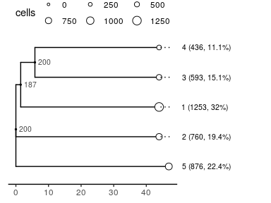

```r
k5_kmeans$tree
```

Lets describe the bubbletree:

**bubbles**: The bubbletree has `k=5` bubbles (clusters) shown as leaves. The absolute and relative cell frequencies in each bubble and the bubble IDs are shown as labels. Bubble radii scale linearly with absolute cell count in each bubble, i.e. large bubbles have many cells and small bubbles contain few cells.

Bubble 1 is the largest one in the dendrogram and contains 1,253 cells ($\approx$ 32% of all cells in the dataset). Bubble 4 is the smallest one and contains only 436 cells ($\approx$ 11% of all cells in the dataset).

We can access the bubble data shown in the bubbletree

```r
knitr::kable(k5_kmeans$tree_meta, digits = 2, row.names = F)
```

| label | c | n | p | pct | tree_order |
| --- | --- | --- | --- | --- | --- |
| 4 | 436 | 3918 | 0.11 | 11.1 | 5 |
| 3 | 593 | 3918 | 0.15 | 15.1 | 4 |
| 1 | 1253 | 3918 | 0.32 | 32.0 | 3 |
| 2 | 760 | 3918 | 0.19 | 19.4 | 2 |
| 5 | 876 | 3918 | 0.22 | 22.4 | 1 |

#### 2.2 with Louvain

Steps 2.2 and 3. (hierarchical clustering) are performed next

```r
k5_louvain <- get_bubbletree_louvain(x = A,
                                     r = 0.0025,
                                     n_start = 20,
                                     iter_max = 100,
                                     louvain_algorithm = "original",
                                     seed = 1234,
                                     cores = 1,
                                     B = 200,
                                     N_eff = 200,
                                     round_digits = 1,
                                     show_simple_count = F)
```

… and plot the bubbletree. We see nearly identical dendrogram as the one generated by kmeans clustering. The bubble IDs are different but we see similar bubble sizes, topology and branch robustness values.

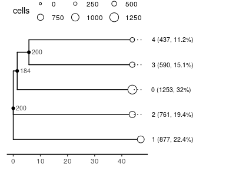

```r
k5_louvain$tree
```

The two dendrograms shown side-by-side:

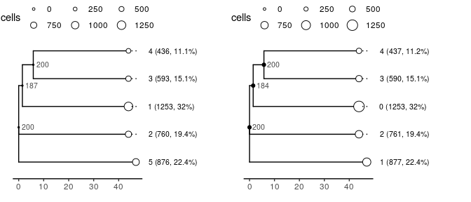

```r
k5_kmeans$tree|k5_louvain$tree
```

Given the high degree of similarity between the two clustering solutions we proceed in the next with the k-means results.

### 4. visualization

To extract biologically useful information from the bubbletree (and also for 2D UMAP or t-SNE plots) we need to adorn it with biologically relevant cell features. This includes both **numeric** and **categorical** cell features.

Numeric cell features:

- gene expression
- % of mitochondrial transcripts
- number of UMIs, genes detected
- …

Categorical cell features:

- cell type label (e.g. B-cells, T-cells, moncytes, …)
- cell cycle phase (e.g. S, M, G1, …)
- sample name (e.g. S1, S2, S3, …)
- treatment group (e.g. cancer vs. control cell)
- multiplet status (e.g. singlet, doublet or multiplet)
- …

In the next two paragraph we will explain how to ‘attach’ numeric and categorical features to the bubbletree using `scBubbletree`.

### attaching categorical features

Categorical cell features can be ‘attached’ to the bubbletree using the function `get_cat_tiles`. Here we will show the relative frequency of cell type labels across the bubbles (parameter `integrate_vertical=T`).

Interpretation of the figure below:

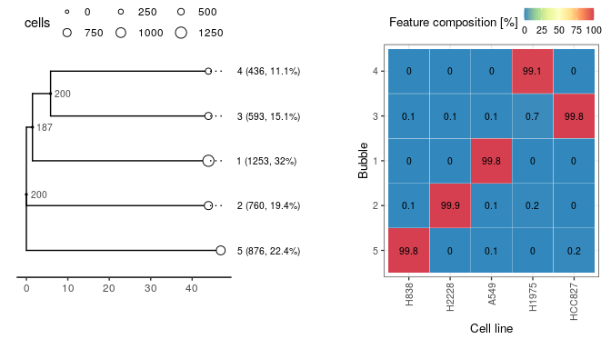

```r
w1 <- get_cat_tiles(btd = k5_kmeans,
                    f = d@meta.data$cell_line_demuxlet,
                    integrate_vertical = T,
                    round_digits = 1,
                    show_hclust = F,
                    disable_hclust = F,
                    x_axis_name = 'Cell line',
                    rotate_x_axis_labels = T,
                    tile_text_size = 2.75)

(k5_kmeans$tree|w1$plot)+
  patchwork::plot_layout(widths = c(1, 1))
```

We can also show the inter-bubble cell type composition, i.e. the relative frequencies of different cell types in a specific bubble (with parameter `integrate_vertical=F`).

Interpretation of the figure below:

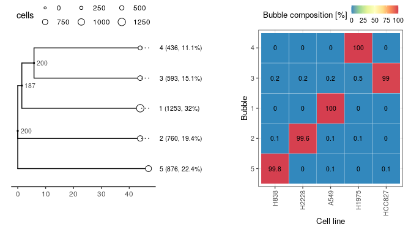

```r
w2 <- get_cat_tiles(btd = k5_kmeans,
                    f = d@meta.data$cell_line_demuxlet,
                    integrate_vertical = F,
                    round_digits = 1,
                    show_hclust = F,
                    disable_hclust = F,
                    x_axis_name = 'Cell line',
                    rotate_x_axis_labels = T,
                    tile_text_size = 2.75)

(k5_kmeans$tree|w2$plot)+
  patchwork::plot_layout(widths = c(1, 1))
```

`scBubbletree` uses R-package `ggtree` to visualize the bubbletree, and `ggplot2` to visualize annotations. Furthermore, R-package `patchwork` is used to combine plots.

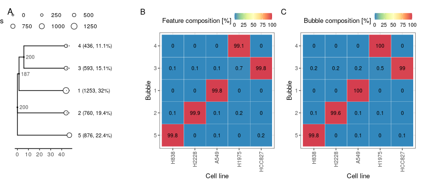

```r
(k5_kmeans$tree|w1$plot|w2$plot)+
  patchwork::plot_layout(widths = c(1, 2, 2))+
  patchwork::plot_annotation(tag_levels = "A")
```